## Introduction

The goal is to use the data to answer a specific set of questions. The data is steps taken by interval over a specific set of dates.

### Loading the libraries needed

```r
library(sqldf)
library(ggplot2)
library(lattice)
```

### Loading the csv

```r
fit_data = read.csv("activity.csv")
```

### Getting total steps per day

- Use sql to get the date and total steps per date
- Create a histogram of the data, and run mean and median functions
- Run the median function over the steps in the dataset
- Run the mean function over the steps in the dataset

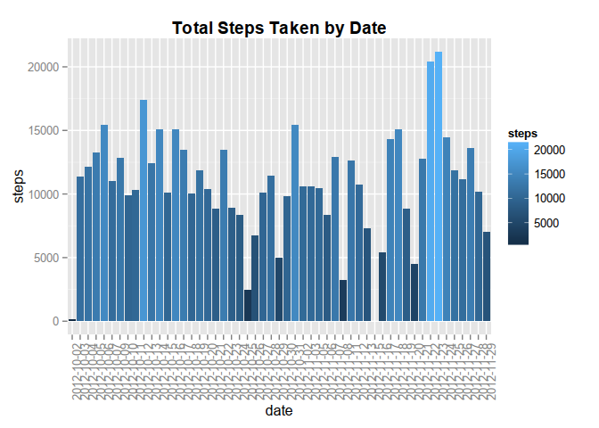

```r
steps <- sqldf("select date, sum(steps) as steps
               from fit_data
               where steps <> 'NA'
               group by date")
steps$steps <- as.numeric(steps$steps)
ggplot(steps, aes(x=date, y=steps, fill=steps)) +
  geom_histogram(stat="identity") +
  theme(axis.text.x = element_text(angle = 90, hjust = 1),
        plot.title = element_text(lineheight=.8, face="bold")) +
  ggtitle("Total Steps Taken by Date")
```

```r
median(steps$steps)
```

```
## [1] 10765
```

```r
mean(steps$steps)
```

```
## [1] 10766.19
```

### Getting the average daily activity pattern

- Use sql get the average steps per interval, then make sure R knows they are numeric
- Use xyplot to create the graph of average steps per interval
- Select the max element from our dataset

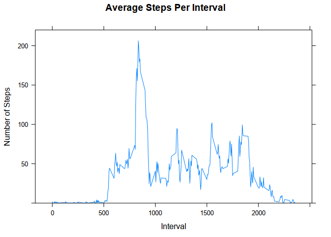

```r
average <- sqldf("select interval, avg(steps) as average
                 from fit_data
                 where steps <> 'NA'
                 group by interval")
average$average <- as.numeric(average$average)
xyplot(average ~ interval,
       ylim=c(0,220),
       data = average,
       type = "l",
       main = "Average Steps Per Interval",
       xlab = "Interval",
       ylab = "Number of Steps")
```

```r
sqldf("select max(average), interval
      from average")
```

```
##   max(average) interval
## 1     206.1698      835
```

### Replacing NA values with the average values for those intervals

- Run the sum over the is.na function to find total number of NAs
- Use sql to get average of steps by interval, and making sure R knows the averages are numeric
- Find all the missing values in the first dataset and join it onto the averages
- Select out only the averages for all missing internals
- Create a copy of the original dataset and overwrite the NA values with the new pulled averages
- Use sql to pull the new averages per date from the newly create NA free dataset
- Use ggplot to create a graph of the new averages per date
- Use the mean and median functions to find how the NA free dataset compares to the one with NAs

```r
sum(is.na(fit_data$steps))
```

```
## [1] 2304
```

```r
average <- sqldf("select interval, avg(steps) as average
                 from fit_data
                 where steps <> 'NA'
                 group by interval")
average$average <- as.numeric(average$average)
missing <- fit_data[is.na(fit_data$steps),]
found <- sqldf("select average as steps, date, m.interval from
               missing m inner join average a
               on m.interval = a.interval")
no_na_data <- fit_data
no_na_data[is.na(fit_data$steps),] <- found
sum(is.na(no_na_data$steps))
```

```
## [1] 0
```

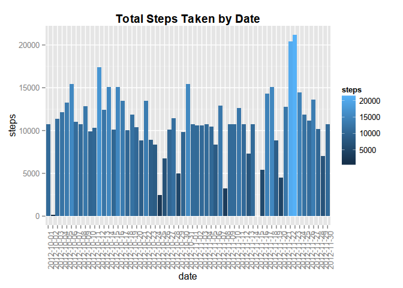

```r
no_na_steps <- sqldf("select date, sum(steps) as steps
                     from no_na_data
                     group by date")
ggplot(no_na_steps,
       aes(x=date, y=steps, fill=steps)) +
  geom_histogram(stat="identity") +
  theme(axis.text.x = element_text(angle = 90, hjust = 1),
        plot.title = element_text(lineheight=.8, face="bold")) +
  ggtitle("Total Steps Taken by Date")
```

```r
median(no_na_steps$steps)
```

```
## [1] 10766.19
```

```r
mean(no_na_steps$steps)
```

```
## [1] 10766.19
```

The median is now different from the dataset that had the NAs. The mean does remain the same.

### Finally, compare activity patterns between Weekday and Weekend

- Make sure the date column is a Date type in R
- Use the weekend function on the date column and insert it into the dataframe as a new column
- Use sql to create a new dataframe with Weekday and Weekend values for each date
- Use sql to create an average steps per date with a factor of part of week
- Use lattice to plot the Average Steps Per Interval factored by part of week

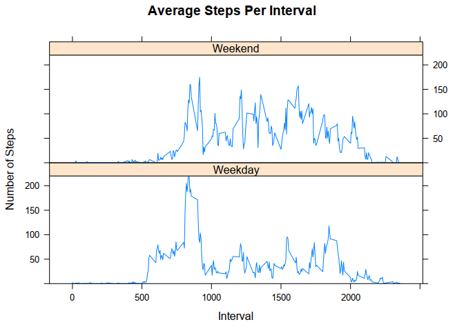

```r
fit_data$date <- as.Date(fit_data$date)
fit_data$day <- weekdays(fit_data$date, abbreviate=TRUE)
weekday <- sqldf("select *, 'Weekend' as week_part
                 from fit_data
                 where day in ('Sat','Sun')
                 union all
                 select *, 'Weekday' as week_part
                 from fit_data
                 where day not in ('Sat','Sun')")
weekday_avg <- sqldf("select interval, week_part, avg(steps) as average
                     from weekday
                     where steps <> 'NA'
                     group by interval, week_part")
weekday_avg$average <- as.numeric(weekday_avg$average)
weekday_avg$week_part <- as.factor(weekday_avg$week_part)
xyplot(average ~ interval | week_part,
       layout=c(1,2),
       ylim=c(0,220),
       data = weekday_avg,
       type = "l",
       main = "Average Steps Per Interval",
       xlab = "Interval",
       ylab = "Number of Steps")
```